# Analyse d’un jeu de données simulé

Karim Barigou

2026-10-05

# 1 Introduction

Ce document présente la simulation des données étudiées dans le cours ainsi que la modélisation à l’aide d’arbres de décision avec le package **rpart**. L’analyse comprend les étapes suivantes :

- Simulation du jeu de données.
- Ajustement de modèles d’arbres avec différentes profondeurs maximales.
- Visualisation des modèles d’arbres.
- Élagage itératif de l’arbre afin d’identifier le modèle optimal à partir de la validation croisée.

# 2 Configuration

Nous chargeons les bibliothèques nécessaires.

```r
# Définir une graine pour assurer la reproductibilité
set.seed(123)

# Charger les bibliothèques nécessaires
library(rpart)
library(rpart.plot)
```

# 3 Simulation des données

Nous simulons un jeu de données contenant 1 000 000 d’observations. Le jeu de données comprend quatre covariables : le sexe (homme ou femme), l’âge (de 18 à 65 ans), le fractionnement de la prime annuelle (oui ou non) et le fait de posséder une voiture de sport (oui ou non). Nous calculons ensuite la fréquence attendue des sinistres et simulons le nombre de sinistres.

```r
# Nombre de simulations
n <- 1000000

# Simulation des variables explicatives
X1 <- sample(c("femme", "homme"), size = n, replace = TRUE, prob = c(0.5, 0.5))
X2 <- sample(18:65, size = n, replace = TRUE, prob = rep(1/48, 48))
X3 <- sample(c("oui", "non"), size = n, replace = TRUE, prob = c(0.5, 0.5))
X4 <- sample(c("oui", "non"), size = n, replace = TRUE, prob = c(0.5, 0.5))

# Calcul de la fréquence attendue des sinistres μ(x)
mu <- 0.1 *
  (1 + 0.1 * (X1 == "homme")) *
  (1 + 0.4 * (X2 >= 18 & X2 < 30) + 0.2 * (X2 >= 30 & X2 < 45)) *
  (1 + 0.15 * (X4 == "oui"))

# Simulation de la variable réponse Y
# selon une loi de Poisson
Y <- rpois(n, lambda = mu)

# Création d'un dataframe
data <- data.frame(
  Y,
  Sexe = X1,
  Age = X2,
  Fractionnement = X3,
  Sport = X4
)

# Affichage des 10 premières lignes du jeu de données
head(data, 10)
```

```
##    Y  Sexe Age Fractionnement Sport
## 1  0 homme  47            non   oui
## 2  0 femme  30            non   oui
## 3  0 homme  22            oui   non
## 4  0 femme  52            oui   oui
## 5  0 femme  47            non   oui
## 6  0 homme  59            oui   oui
## 7  0 femme  54            oui   non
## 8  0 femme  33            oui   oui
## 9  0 femme  38            oui   oui
## 10 0 homme  60            non   non
```

# 4 Ajustement d’un modèle d’arbre — profondeur maximale = 3

```r
# Ajustement du modèle d'arbre avec une profondeur maximale de 3
tree <- rpart(
  Y ~ Sexe + Age + Fractionnement + Sport,
  data = data,
  method = "poisson",
  control = rpart.control(
    minsplit = 50,
    cp = 0,
    maxdepth = 3
  )
)

# Affichage de la structure de l'arbre
print(tree)
```

```
## n= 1000000
##
## node), split, n, deviance, yval
##       * denotes terminal node
##
##  1) root 1000000 557414.10 0.13156700
##    2) Age>=44.5 438231 223211.20 0.11284490
##      4) Sport=non 219442 106816.80 0.10468920
##        8) Sexe=femme 109809  51793.11 0.09961153 *
##        9) Sexe=homme 109633  54969.52 0.10977690 *
##      5) Sport=oui 218789 116135.00 0.12102560
##       10) Sexe=femme 108963  56164.47 0.11501270 *
##       11) Sexe=homme 109826  59905.66 0.12699210 *
##    3) Age< 44.5 561769 332096.80 0.14617200
##      6) Age>=29.5 312481 177117.20 0.13556330
##       12) Sport=non 156352  84774.38 0.12532650 *
##       13) Sport=oui 156129  92100.72 0.14581460 *
##      7) Age< 29.5 249288 154440.10 0.15946930
##       14) Sport=non 124318  73912.90 0.14791000 *
##       15) Sport=oui 124970  80319.21 0.17096660 *
```

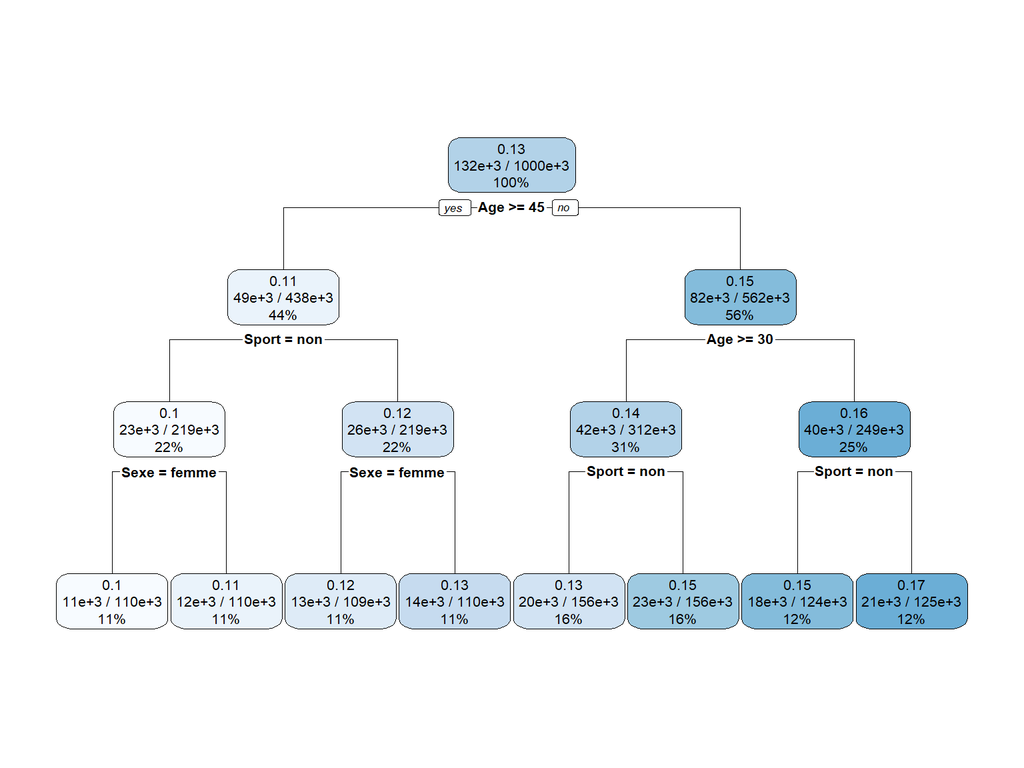

```r
# Représentation graphique de l'arbre
rpart.plot(tree)
```

# 5 Ajustement d’un arbre complet — profondeur maximale = 4

Nous ajustons ensuite un arbre complet avec une profondeur maximale de 4. Comme nous l’avons vu dans le cours, ce modèle conduit à un **sur-ajustement**, car certaines branches inutiles apparaissent dans l’arbre.

```r
# Ajustement du modèle d'arbre avec une profondeur maximale de 4
fulltree <- rpart(
  Y ~ Sexe + Age + Fractionnement + Sport,
  data = data,
  method = "poisson",
  control = rpart.control(
    cp = 0,
    maxdepth = 4
  )
)

# Affichage de la structure de l'arbre
print(fulltree)
```

```
## n= 1000000
##
## node), split, n, deviance, yval
##       * denotes terminal node
##
##  1) root 1000000 557414.100 0.13156700
##    2) Age>=44.5 438231 223211.200 0.11284490
##      4) Sport=non 219442 106816.800 0.10468920
##        8) Sexe=femme 109809  51793.110 0.09961153
##         16) Age< 45.5 5283   2426.332 0.09450723 *
##         17) Age>=45.5 104526  49365.280 0.09987219 *
##        9) Sexe=homme 109633  54969.520 0.10977690
##         18) Age< 48.5 21052  10382.160 0.10650720 *
##         19) Age>=48.5 88581  44584.790 0.11055600 *
##      5) Sport=oui 218789 116135.000 0.12102560
##       10) Sexe=femme 108963  56164.470 0.11501270
##         20) Age< 59.5 77713  39704.780 0.11339340 *
##         21) Age>=59.5 31250  16453.540 0.11904300 *
##       11) Sexe=homme 109826  59905.660 0.12699210
##         22) Age>=64.5 5324   2763.800 0.11778830 *
##         23) Age< 64.5 104502  57138.030 0.12746200 *
##    3) Age< 44.5 561769 332096.800 0.14617200
##      6) Age>=29.5 312481 177117.200 0.13556330
##       12) Sport=non 156352  84774.380 0.12532650
##         24) Sexe=femme 77990  41221.050 0.11964470 *
##         25) Sexe=homme 78362  43513.220 0.13098190 *
##       13) Sport=oui 156129  92100.720 0.14581460
##         26) Sexe=femme 77757  44511.150 0.13809630 *
##         27) Sexe=homme 78372  47526.250 0.15347110 *
##      7) Age< 29.5 249288 154440.100 0.15946930
##       14) Sport=non 124318  73912.900 0.14791000
##         28) Sexe=femme 61994  35656.240 0.13957700 *
##         29) Sexe=homme 62324  38198.580 0.15619690 *
##       15) Sport=oui 124970  80319.210 0.17096660
##         30) Sexe=femme 62671  39534.270 0.16458570 *
##         31) Sexe=homme 62299  40755.020 0.17738090 *
```

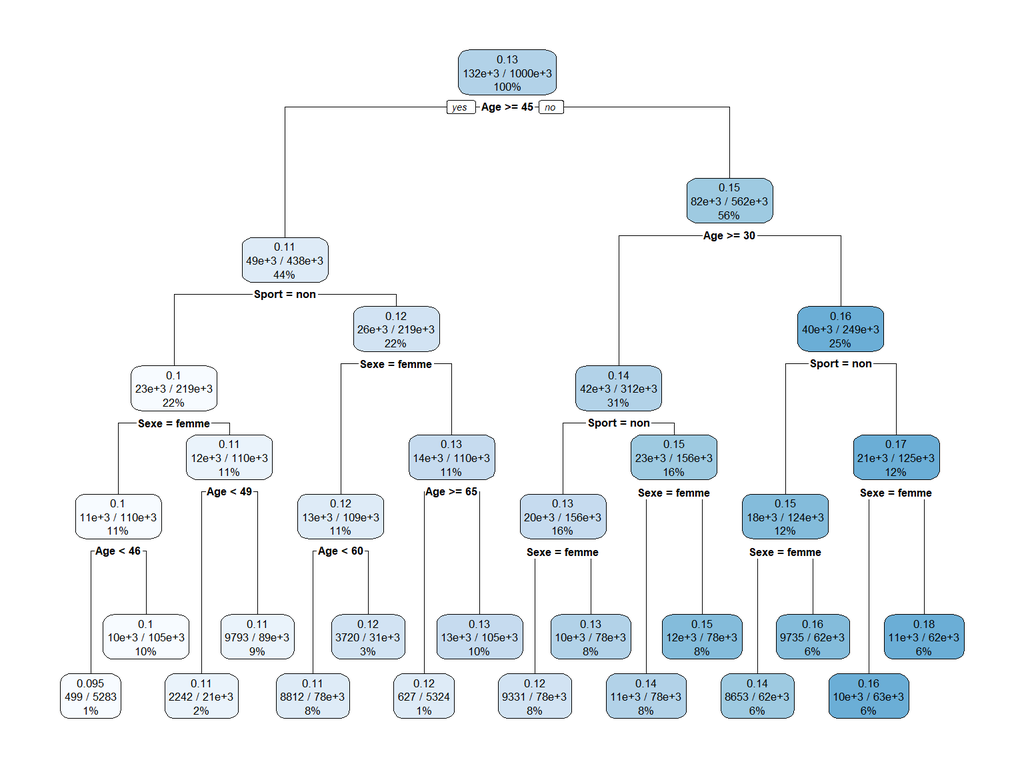

```r
# Représentation graphique de l'arbre
rpart.plot(fulltree)
```

```r
# Affichage des paramètres de complexité
printcp(fulltree)
```

```
##
## Rates regression tree:
## rpart(formula = Y ~ Sexe + Age + Fractionnement + Sport, data = data,
##     method = "poisson", control = rpart.control(cp = 0, maxdepth = 4))
##
## Variables actually used in tree construction:
## [1] Age   Sexe  Sport
##
## Root node error: 557414/1000000 = 0.55741
##
## n= 1000000
##
##            CP nsplit rel error  xerror      xstd
## 1  3.7784e-03      0   1.00000 1.00000 0.0016282
## 2  9.6781e-04      1   0.99622 0.99623 0.0016233
## 3  4.6524e-04      2   0.99525 0.99527 0.0016224
## 4  4.3440e-04      3   0.99479 0.99497 0.0016222
## 5  3.7313e-04      4   0.99435 0.99444 0.0016215
## 6  1.1643e-04      5   0.99398 0.99401 0.0016209
## 7  1.1361e-04      6   0.99386 0.99400 0.0016211
## 8  1.0421e-04      7   0.99375 0.99394 0.0016211
## 9  9.7195e-05      8   0.99365 0.99384 0.0016209
## 10 7.1961e-05      9   0.99355 0.99361 0.0016204
## 11 5.3693e-05     10   0.99348 0.99356 0.0016204
## 12 1.1016e-05     11   0.99342 0.99348 0.0016204
## 13 6.8843e-06     12   0.99341 0.99350 0.0016204
## 14 4.6082e-06     13   0.99341 0.99352 0.0016205
## 15 2.7011e-06     14   0.99340 0.99352 0.0016205
## 16 0.0000e+00     15   0.99340 0.99352 0.0016205
```

# 6 Élagage de l’arbre

D’après le tableau des paramètres de complexité, nous savons que l’arbre optimal — c’est-à-dire l’arbre qui minimise l’erreur de validation croisée à 10 plis — est obtenu en élaguant l’arbre quatre fois de manière itérative. Pour cela, nous extrayons le tableau des paramètres de complexité et effectuons plusieurs étapes successives d’élagage.

```r
# Extraction du tableau des paramètres de complexité
cp_table <- fulltree$cptable

# Récupération de la valeur de cp située avant la dernière ligne
# et affichage de cette valeur
before_last_cp <- cp_table[nrow(cp_table) - 1, "CP"]
print(before_last_cp)
```

```
## [1] 2.701102e-06
```

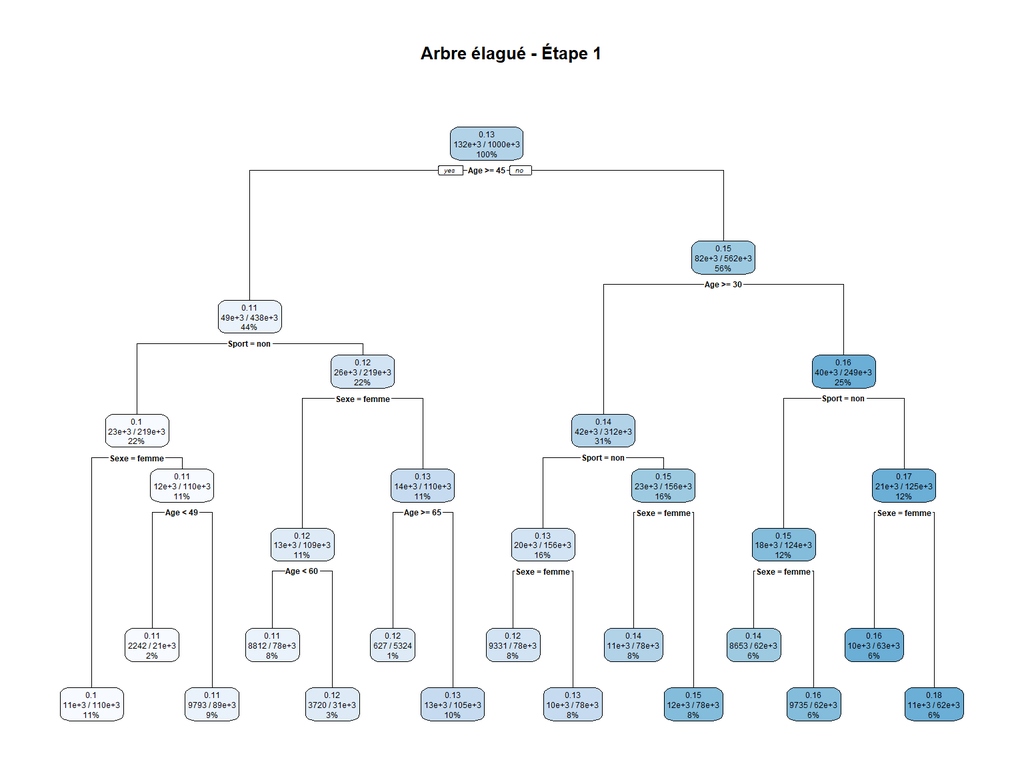

```r
# Premier élagage de l'arbre à partir de l'avant-dernière valeur de cp
tree_pruned_1 <- prune(
  fulltree,
  cp = cp_table[nrow(cp_table) - 1, "CP"]
)

rpart.plot(
  tree_pruned_1,
  main = "Arbre élagué - Étape 1"
)
```

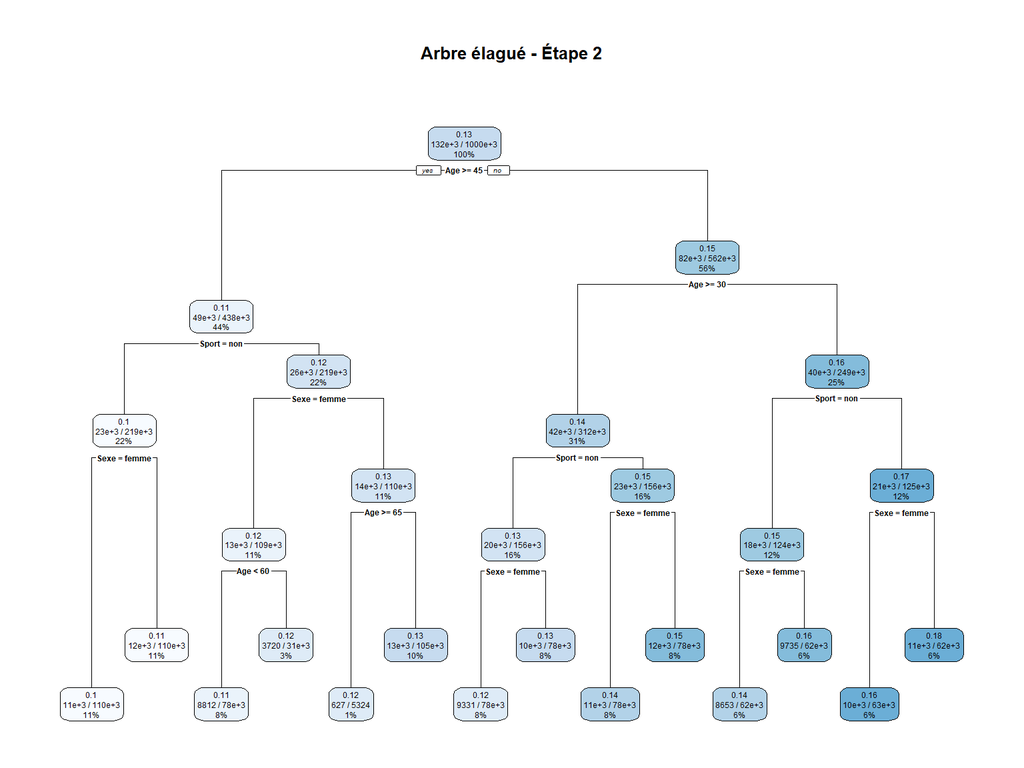

```r
# Élagage supplémentaire à partir de la valeur de cp précédente
tree_pruned_2 <- prune(
  tree_pruned_1,
  cp = cp_table[nrow(cp_table) - 2, "CP"]
)

rpart.plot(
  tree_pruned_2,
  main = "Arbre élagué - Étape 2"
)
```

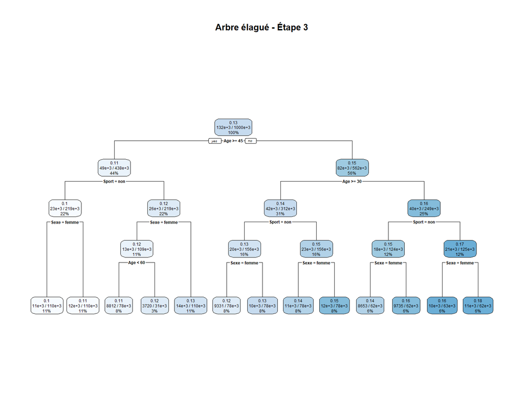

```r
# Poursuite de l'élagage de manière itérative
tree_pruned_3 <- prune(
  tree_pruned_2,
  cp = cp_table[nrow(cp_table) - 3, "CP"]
)

rpart.plot(
  tree_pruned_3,
  main = "Arbre élagué - Étape 3"
)
```

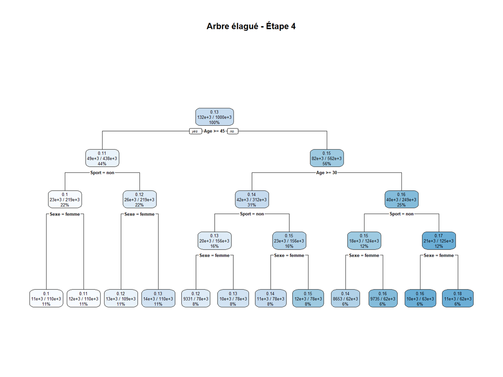

```r
tree_pruned_4 <- prune(
  tree_pruned_3,
  cp = cp_table[nrow(cp_table) - 4, "CP"]
)

rpart.plot(
  tree_pruned_4,
  main = "Arbre élagué - Étape 4"
)
```

```r
# Affichage du tableau des paramètres de complexité
# pour l'arbre élagué, représentant l'arbre optimal
# selon la validation croisée
printcp(tree_pruned_4)
```

```
##
## Rates regression tree:
## rpart(formula = Y ~ Sexe + Age + Fractionnement + Sport, data = data,
##     method = "poisson", control = rpart.control(cp = 0, maxdepth = 4))
##
## Variables actually used in tree construction:
## [1] Age   Sexe  Sport
##
## Root node error: 557414/1000000 = 0.55741
##
## n= 1000000
##
##            CP nsplit rel error  xerror      xstd
## 1  3.7784e-03      0   1.00000 1.00000 0.0016282
## 2  9.6781e-04      1   0.99622 0.99623 0.0016233
## 3  4.6524e-04      2   0.99525 0.99527 0.0016224
## 4  4.3440e-04      3   0.99479 0.99497 0.0016222
## 5  3.7313e-04      4   0.99435 0.99444 0.0016215
## 6  1.1643e-04      5   0.99398 0.99401 0.0016209
## 7  1.1361e-04      6   0.99386 0.99400 0.0016211
## 8  1.0421e-04      7   0.99375 0.99394 0.0016211
## 9  9.7195e-05      8   0.99365 0.99384 0.0016209
## 10 7.1961e-05      9   0.99355 0.99361 0.0016204
## 11 5.3693e-05     10   0.99348 0.99356 0.0016204
## 12 1.1016e-05     11   0.99342 0.99348 0.0016204
```